# R code for Figures 7 main and figure supplement 1 - Interindividual variability that is not explained by clinical data

Xiao Xu (xxu@rockefeller.edu)

July 2018

Xu X, Stoyanova EI, Lemiesz A, Xing J, Mash DC, Heintz N (2018). Species and Cell-Type Properties of Classically Defined Human and Rodent Neurons and Glia.

Specifically, this workflow will analyze whether there exists interindividual variability that is not explianed by known clinical factors. It will also generate the MA plot and cnet plot of GO terms.

Load libraries and functions:

```r
# source custom functions
source("functions.R")
# libraries for gene expression analysis
library(DESeq2)
# libraries for heatmaps and colors
library(RColorBrewer)
library(gplots)
# for GO analysis
library(org.Hs.eg.db)
library(clusterProfiler)
# work in the tidyverse
library(tidyverse)
library(ggrepel)
library(grid)
library(gridExtra)
library(reshape2)
library(ggbeeswarm)
```

## PCA to identify unknown sources of variability

Load counts and metadata for human samples. Also laod normalized counts from figure 5.

```r
counts <- read_tsv("../data/human_all_wg_counts.txt")
meta <- read_tsv("../data/human_metadata.txt")
rld_table <- read_rds("../data_clean/figure_5_main_human_all_norm_rld.RDS") %>%
  assay() %>%
  as.data.frame() %>%
  rownames_to_column("Gene")
```

Define some functions to calculate PCA and produce plots

```r
plotPCA <- function(pca, x, y, leg = TRUE) {
  #cell_cols <- c("granule" = "green", "basket" = "orange", "glia" = "blue")
  p <- ggplot(pca, mapping = aes_string(x, y, label = "Donor")) +
    geom_point(aes(color = Gender, size = Age, shape = Race),
               alpha = 0.7) +
    geom_text_repel(size = 12) +
    scale_color_manual(values = c("orchid2", "royalblue2")) +
    theme_bw()

  if(leg)
    p <- p + theme(legend.position="none")

  return(p)
}
plotPCAScoresAndLoadings <- function(meta, norm_counts, ct) {
  # subset by cell type
  meta_sub <- meta %>%
    filter(Cell_type == ct)
  norm_counts_sub <- norm_counts %>%
    select(Gene, meta_sub$Sample)

  # get PCA scores and loadings
  pca <- calcPCAScoresAndLoadings(norm_counts_sub)



  # plot contribution to variance for first 8 principal components
  plot( plotPCImportance(pca[["scores"]]) )
  ggsaveToPdf( paste("../figures/figure_7_main_pca_importance_", ct, ".pdf", sep = "") )

  # join scores with metadata
  pca_annot <- pca[["scores"]] %>%
    rownames_to_column("Sample") %>%
    left_join(meta_sub, by = "Sample")

  # plot loadings along side score for PC1 vs PCs2, 3, or 4
  # all plots are saving to file but not sure why only
  # last plot is showing up in notebook
  lapply( c("PC4", "PC3", "PC2"),
          function(x) {
            g <- arrangeGrob(
              plotTopNLoadings(pca[["loadings"]], "PC1", x),
              plotPCA(pca_annot, "PC1", x),
              ncol = 2
              )
            ggsaveToPdf(
              paste("../figures/figure_7_main_pca_", ct, "_PC1_vs_", x, ".pdf", sep = ""),
              plot = g
              )
            grid.draw(g, recording = FALSE)
          })

  # save single plot with legend
  plotPCA(pca_annot, "PC1", "PC2", leg = FALSE)
  ggsaveToPdf( paste("../figures/figure_7_main_pca_", ct,
                     "_PC1_vs_PC2_with_legend.pdf", sep = "") )

  # return table with proportion variance for each pc
  prop_var <- tibble(
    Cell_type = rep(ct, 8),
    Name = attributes(pca[["scores"]])$names,
    Percent_var = attributes(pca[["scores"]])$percentVar
  )
  return(prop_var)
}
```

For each cell type, perform PCA, plot scores and loadings. Return table with proportion variability for each PC.

| Cell_type | Name | Percent_var |
| --- | --- | --- |
| granule | PC1 | 0.26679341 |
| granule | PC2 | 0.24447821 |
| granule | PC3 | 0.09259687 |
| granule | PC4 | 0.07265838 |
| granule | PC5 | 0.06606255 |
| granule | PC6 | 0.04406325 |
| granule | PC7 | 0.03827250 |
| granule | PC8 | 0.03262399 |

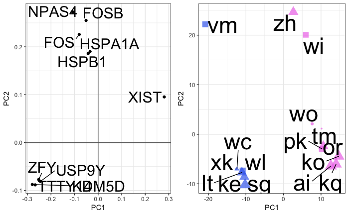

```r
plotPCAScoresAndLoadings(meta, rld_table, "granule")
```

| Cell_type | Name | Percent_var |
| --- | --- | --- |
| glia | PC1 | 0.26188118 |
| glia | PC2 | 0.15452109 |
| glia | PC3 | 0.10559054 |
| glia | PC4 | 0.09106167 |
| glia | PC5 | 0.07663697 |
| glia | PC6 | 0.06972198 |
| glia | PC7 | 0.05021530 |
| glia | PC8 | 0.04372012 |

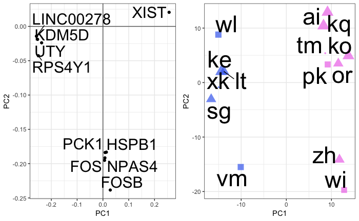

```r
plotPCAScoresAndLoadings(meta, rld_table, "glia")
```

| Cell_type | Name | Percent_var |
| --- | --- | --- |
| basket | PC1 | 0.37223162 |
| basket | PC2 | 0.19224577 |
| basket | PC3 | 0.08996764 |
| basket | PC4 | 0.05359696 |
| basket | PC5 | 0.04483403 |
| basket | PC6 | 0.03986837 |
| basket | PC7 | 0.03698349 |
| basket | PC8 | 0.03152336 |

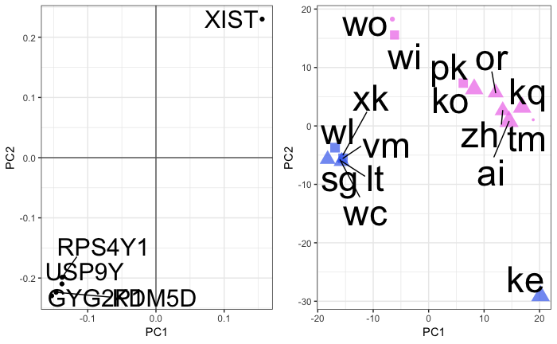

```r
plotPCAScoresAndLoadings(meta, rld_table, "basket")
```

## DE analysis

Perform differential expression analysis to get full list of DE granule cell genes between individuals VM, ZH, and WI compared to the other indivdiuals.

Helper function

```r
getDE <- function(counts, meta, cell_type) {
  fos_donors <- c("vm", "zh", "wi")
  meta_sub <- meta %>%
    filter(Cell_type == cell_type) %>%
    mutate(Group = ifelse(Donor %in% fos_donors,
                          "Fos", "Not_fos"))
  counts_sub <- counts %>%
    select(Gene, meta_sub$Sample)

  # deseq
  dds <- DESeqDataSetFromMatrix(counts_sub %>% column_to_rownames("Gene"),
                                meta_sub %>% column_to_rownames("Sample"),
                                design = ~ Group)
  dds <- DESeq(dds)

  de <- results(dds, contrast = c("Group", "Fos", "Not_fos"))
  de_table <- de %>%
    as.data.frame() %>%
    rownames_to_column("Gene") %>%
    arrange(padj)

  write_tsv(de_table, paste("../output/figure_7_main_de_fos_", cell_type, ".txt", sep = ""))

  # number of up and down-regulated significant genes
  p_cutoff <- 0.01
  bm_cutoff <- 50
  print(
    de_table %>%
      filter(padj < p_cutoff, baseMean > bm_cutoff) %>%
      group_by(log2FoldChange > 0) %>%
      count()
  )

  return(de_table)
}
```

Run DEseq2 and output DE genes

```r
cts <- c("granule", "glia", "basket")
de_fos <- lapply(
  cts,
  getDE,
  counts = counts,
  meta = meta
)
```

| log2FoldChange > 0 | n |
| --- | --- |
| FALSE | 10 |
| TRUE | 224 |

| log2FoldChange > 0 | n |
| --- | --- |
| TRUE | 136 |

| log2FoldChange > 0 | n |
| --- | --- |
| TRUE | 2 |

```r
names(de_fos) <- cts
```

MA-plots

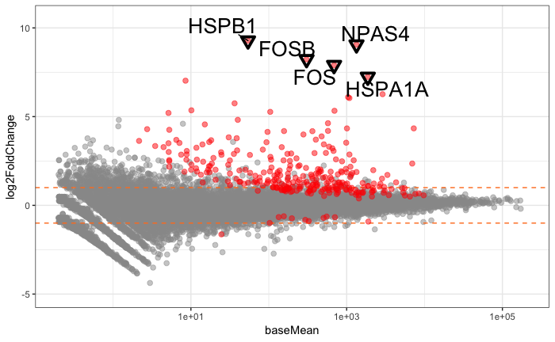

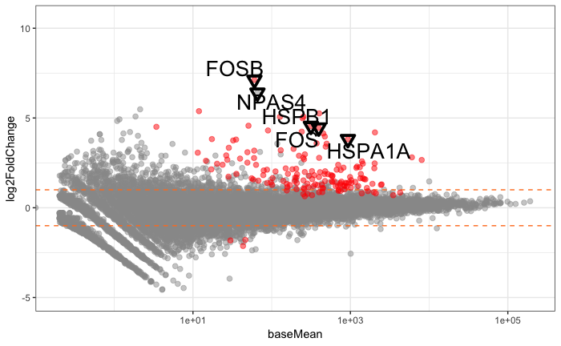

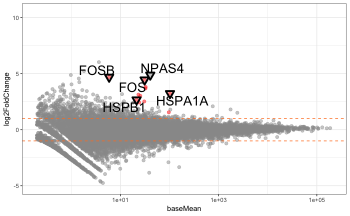

```r
lapply(
  cts,
  function(cell_type) {
    p <- plotMACustom(
      de_fos[[cell_type]],
      markers = tibble(
        Marker = c("FOS", "FOSB", "NPAS4", "HSPA1A", "HSPB1"),
        Direction = rep("Up", 5)
        ),
      point_size = 2,
      sig_col = "red",
      ylims = c(-5, 10.5),
      xlims = c(0.2, 200000)
      )
    print(p)
    ggsaveToPdf(paste("../figures/figure_7_main_ma_fos", cell_type, ".pdf", sep = ""))
  }
)
```

### GO analysis

Run for granule cell induced genes only First run for all three ontologies and write output to disk

```r
fos_up_genes <- de_fos[["granule"]] %>%
  filter(padj < 0.01, baseMean > 50, log2FoldChange > 0) %>%
  pull(Gene)
# run for all three ontologies and write output to disk
ego <- enrichGOCustom(fos_up_genes, ontology = "ALL")
```

```
1.34% of input gene IDs are fail to map...
```

```r
write_tsv(ego %>% as.data.frame(),
          "../output/figure_7_main_go_granule_fos_up.txt")
# run for biologicaly process only for plotting
ego <- enrichGOCustom(fos_up_genes, ontology = "BP")
```

```
1.34% of input gene IDs are fail to map...
```

```r
# save object to disk
write_rds(ego, "../data_clean/figure_7_main_ego_bp.RDS")
```

Make CNET plot

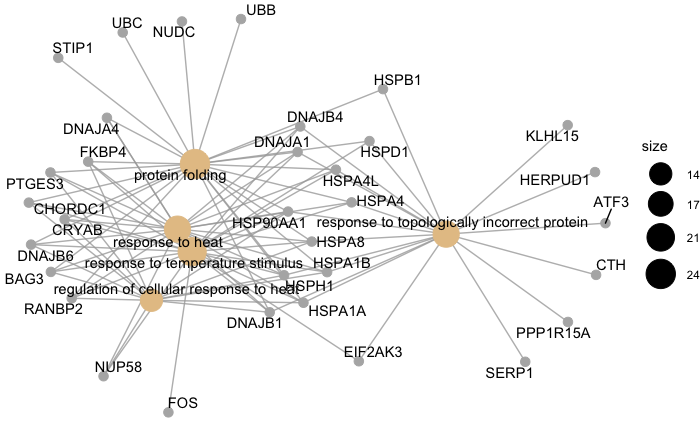

```r
# ego <- read_rds("../data_clean/figure_7_main_ego_bp.RDS")
cnetplot(ego)
ggsaveToPdf("../figures/figure_7_main_go_cnet.pdf")
```

## Heatmap to accompany IGV tracks

Load counts and define metadata for human samples

```r
counts <- read_tsv("../data/human_all_wg_counts.txt")
meta_igv <- tibble(
  Sample = colnames(counts)[-1]
) %>%
  separate(Sample, into = c("ID", "Donor", "Cell_type"), sep = "_", remove = FALSE) %>%
  mutate(Donor_ct = paste(Donor, Cell_type, sep = "_"))
```

Calculate fpkms (rpkms) for visualization.

```r
# read in gene lengths
lengths <- read_tsv("../data/ref/hg38_refseq_wg_longest.txt", col_names = c("Gene", "Length"))
# calculate rpkms
rpkms <- getNormCounts(counts, lengths)
# reorder samples for visualization
donors <- c("wi", "vm", "zh", "xk", "wc", "wl", "sg", "lt", "ke",
            "tm", "wo", "pk", "or", "ko", "kq", "ai")
sample_order <- tibble(
  Cell_type = c(rep("granule", 16), rep("glia", 14), rep("basket", 16)),
  Donor = c(donors, donors[!(donors %in% c("wc", "wo"))], donors)
) %>%
  mutate(Donor_ct = paste(Donor, Cell_type, sep = "_")) %>%
  select(Donor_ct) %>%
  left_join(meta_igv, by = "Donor_ct")
rpkms_ordered <- rpkms[, sample_order$Sample]
```

Genes to visualize

```r
# define genes
genes_granule <- "FAT2"
genes_ieg <- c("ARC", "EGR1", "FOS", "FOSB", "JUN", "NR4A2")
genes_other_induced <- c("DUSP1", "SLC2A3", "BCAS2")
genes_act_astro <- c("GFAP", "S100B")
igv_genes <- c( genes_granule, genes_ieg, genes_other_induced, genes_act_astro )
rpkms_for_igv <- rpkms_ordered[igv_genes, ] %>% t()
```

Specify colors for heatmap:

```r
# palette for rpkms
cor_col <- colorRampPalette( brewer.pal(9, 'YlOrRd') )(100)
cor_breaks <- seq(-2, 12, length.out = 101)
# sidebar for heatmap.2
cell_type_cols <- c(
  Granule = "#33A02C",
  Glia = "blue",
  Basket = "#FF6600"
)
sidebar_row <- rep(cell_type_cols, c(16, 14, 16))
sidebar_col <- c(
  cell_type_cols["Granule"],
  rep( "#990099", length( genes_ieg ) ),
  rep( "plum1", length( genes_other_induced ) ),
  rep( cell_type_cols["Glia"], length( genes_act_astro ) )
)
```

Plot heatmap:

```r
pdf("../figures/figure_7_main_heatmap_fos_for_igv.pdf", width = 11, height = 8.5)
hm <- heatmap.2(
  rpkms_for_igv,
  dendrogram = "none", Rowv = FALSE, Colv = FALSE, # no dendrogram, no reordering
  col = cor_col, breaks = cor_breaks,  # colors for values
  RowSideColors = sidebar_row, ColSideColors = sidebar_col,  # sidebar
  scale = "none", trace = "none",
  key.title = NA, key.ylab = NA,
  cexRow = 1, cexCol = 1, margins = c(2, 2),
  labCol = FALSE, labRow = FALSE, symkey = F,
  keysize = 1, key.par = list(mar = c(4, 2, 1, 1))
)
dev.off()
```

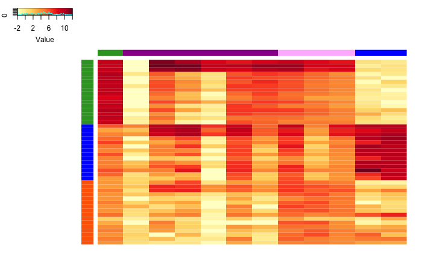

```r
# and display in this file
eval(hm$call)
```

## Permutation analysis

How many genes could come up as significant if performed DE analysis of any 3 individuals against the other 13? Test for all 560 combinations of 3 donors against the other 13.

Define combinations

```r
# create all combinations of 3 donors from the group of 16
combs <- combn(unique(meta$Donor), 3) %>%
  t() %>%
  as.data.frame()
colnames(combs) <- c("Donor_1", "Donor_2", "Donor_3")
# how many combinations?
nrow(combs)
```

```
[1] 560
```

For each combination of 3 donors in group A and 13 donors in group B, perform differential expression analysis and report number of genes that pass significance (padj < 0.01, baseMean > 50).

```r
getNDESigForPerm <- function(meta, counts, donors, p_cutoff = 0.01, bm_cutoff = 50) {
  donors_sub <- unlist(donors)
  meta_sub <- meta %>%
    mutate(Group = ifelse(Donor %in% donors_sub,
                          "A", "B"))
  counts_sub <- counts %>%
    select(Gene, meta_sub$Sample)

  # deseq
  dds <- DESeqDataSetFromMatrix(counts_sub %>% column_to_rownames("Gene"),
                                meta_sub %>% column_to_rownames("Sample"),
                                design = ~ Group)
  dds <- DESeq(dds)

  de <- results(dds, contrast = c("Group", "A", "B"))
  de_table <- de %>%
    as.data.frame() %>%
    rownames_to_column("Gene")

  # number of differentially expressed genes
  n_sig <- de_table %>%
    filter(padj < p_cutoff, baseMean > bm_cutoff) %>%
    nrow

  return(n_sig)
}

meta_sub <- meta %>% filter(Cell_type == "granule")
comb_n_sig <- apply(combs, 1,
                    function(x)
                      getNDESigForPerm(meta_sub, counts, x)
                    )
```

Add number of significant genes as column to combination metadata and save to disk.

```r
n_fos_donors <- apply(combs, 1, function(x) length(intersect(x, fos_donors)))
combs_sig <- combs %>%
  mutate(n_fos = n_fos_donors) %>%
  mutate(n_sig = comb_n_sig) %>%
  arrange(desc(n_sig))
write_tsv(combs_sig, "../output/figure_7_s1_permutation_n_sig.txt")
```

Plot histogram of significant genes

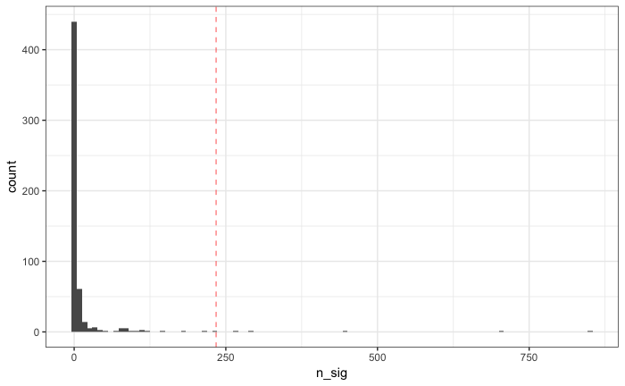

```r
combs_sig <- read_tsv("../output/figure_7_s1_permutation_n_sig.txt")
ggplot(combs_sig, aes(n_sig)) +
  geom_histogram(bins = 100) +
  geom_vline(xintercept = 234, color = "red", alpha = 0.5, linetype = 2) +
  theme_bw()
ggsaveToPdf("../figures/figure_7_s1_permutation_histogram.pdf")
```

```r
combs_sig %>%
  group_by(n_sig > 50, n_sig >= 234, n_fos >= 2) %>%
  count()
```

| n_sig > 50 | n_sig >= 234 | n_fos >= 2 | n |
| --- | --- | --- | --- |
| FALSE | FALSE | FALSE | 503 |
| FALSE | FALSE | TRUE | 26 |
| TRUE | FALSE | FALSE | 12 |
| TRUE | FALSE | TRUE | 13 |
| TRUE | TRUE | FALSE | 5 |
| TRUE | TRUE | TRUE | 1 |

Half of the combinations that yield 50 or more DE genes contain at least 2 donors with fos gene expression. Why are the others coming up? Check age.

```r
# create age lookup table
donor_ages <- meta %>% filter(Cell_type == "granule") %>% pull(Age)
names(donor_ages) <- meta %>% filter(Cell_type == "granule") %>% pull(Donor)
# add ages of 3 donors
# calculate median age of 3 donors and median age of other 13 donors
# calculate difference in age
combs_sig_annot <- combs_sig %>%
  mutate_if(is.factor, as.character) %>%
  mutate(Age_1 = donor_ages[Donor_1]) %>%
  mutate(Age_2 = donor_ages[Donor_2]) %>%
  mutate(Age_3 = donor_ages[Donor_3]) %>%
  rowwise() %>%
  mutate(Age_median = median(c(Age_1, Age_2, Age_3))) %>%
  mutate(Age_median_others = median(
    donor_ages[!(names(donor_ages) %in% c(Donor_1, Donor_2, Donor_3))]
    )
  ) %>%
  mutate(Age_diff = Age_median_others - Age_median) %>%
  mutate(Sig_group = ifelse(n_sig >= 234, TRUE, FALSE)) %>%
  mutate(Fos_group = ifelse(n_fos >= 2, TRUE, FALSE))
```

Plot histogram of age difference. Looks like most of the non-fos combinations can be explained by groups containing very young or very old donors, so the significant genes likely represent aging genes.

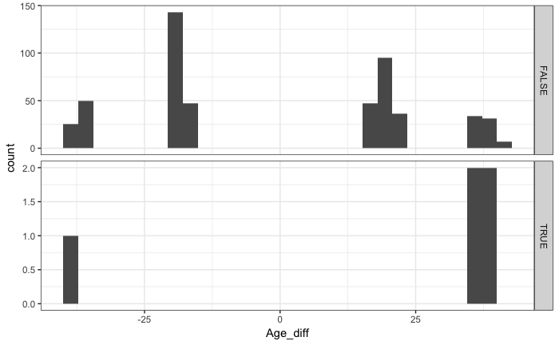

```r
ggplot(combs_sig_annot %>% filter(!Fos_group), aes(Age_diff)) +
  geom_histogram() +
  facet_grid(Sig_group ~ ., scales = "free_y") +
  theme_bw()
ggsaveToPdf("../figures/figure_7_s1_permutation_sig_age_diff.pdf")
```

Plot as violin plot

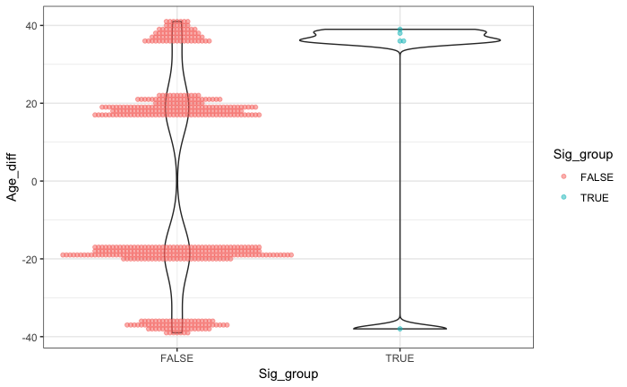

```r
ggplot(combs_sig_annot %>% filter(!Fos_group), aes(x = Sig_group, y = Age_diff)) +
  geom_violin(alpha = 0.5) +
  geom_beeswarm(aes(color = Sig_group), alpha = 0.5, cex = 0.8, size = 1.4) +
  theme_bw()
ggsaveToPdf("../figures/figure_7_s1_permutation_sig_age_diff_violin.pdf")
```